# East Brunswick Township School District — NJ School Data Almanac – NJ District Profiles

NJ School Data Almanac

East Brunswick Township School District

MIDDLESEX COUNTY · TRADITIONAL PUBLIC DISTRICT · DFG I · 7,980 STUDENTS (2026)

7,980

Students

96.2%

4-yr grad rate

68.2%

Gr 3-8 ELA

8.9%

Chronically absent

$19,096

Per pupil

*10 things the data says about East Brunswick Township School District. Every figure is computed from New Jersey Department of Education data via the njschooldata package — nothing is estimated. Comparisons use District Factor Group (DFG) peers (103 districts in DFG I).*

No. 1 ACHIEVEMENT

## Six Years On, East Brunswick’s Elementary Math Proficiency Is Still 9 Points Below Where It Started in 2019

An affluent, high-performing district recovered some of its pandemic learning loss in grades 3-8, but its math and reading scores remain stuck below their pre-COVID levels.

East Brunswick is the kind of district where families expect academic results near the top of the state, and its high-school AP and graduation numbers deliver. But the elementary and middle-school picture, newly visible through NJSLA results for grades 3 through 8, tells a slower-healing story.

In 2019, 68.1% of East Brunswick’s students in grades 3-8 scored proficient or above in math. The pandemic drove that figure down to 56.5% by 2022, and the recovery since has been partial: 59.5% in 2023 and 59.0% in 2024, still about 9 percentage points below the 2019 baseline. Reading followed a gentler version of the same arc, falling 7.6 points from 73.5% in 2019 to 65.9% in 2022 before edging back to 68.2% by 2024, roughly 5 points short of where it began.

The high-school signal is brighter. On the NJGPA graduation-proficiency math test, the district climbed from 74.7% in 2023 to 79.7% in 2025. That contrast raises a pointed question for families and the board: if East Brunswick’s oldest students are clearing the state bar at nearly 80%, why have its youngest classes not yet returned to their own pre-pandemic level, and what will it take to close the remaining gap?

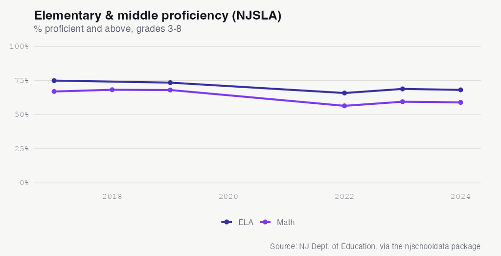

See the underlying data ›

No. 2 EQUITY

## In East Brunswick, Asian Students Pass State Reading at 85.7% While White Students Pass at 62.1% — a 24-Point Gap

The district’s 2024 NJSLA reading results invert the usual achievement-gap script, with its largest racial group well below its second-largest.

Achievement-gap stories usually run in a familiar direction. East Brunswick’s 2024 NJSLA reading results for grades 3-8 do not. Among the district’s two largest groups, Asian students scored proficient or above at 85.7%, more than 23 percentage points higher than white students at 62.1% — and white students landed below the districtwide average of 68.2%.

The more conventional gaps are present too, and they are wide. Students who are economically disadvantaged passed at 49.6% against 72.9% for their more-advantaged peers, a 23-point divide. Hispanic students passed at 50.1%, Black students at 56.5%, students with disabilities at 25.0%, and multilingual learners who are still current English learners at just 6.7%. From the top of the distribution to the bottom, East Brunswick’s reading proficiency spans nearly 80 percentage points.

The Asian-over-white inversion is the most distinctive feature, and it complicates any single narrative about who the district serves well. With its largest group performing below its own average in reading, how is East Brunswick reading these numbers, and which groups will its next round of supports target?

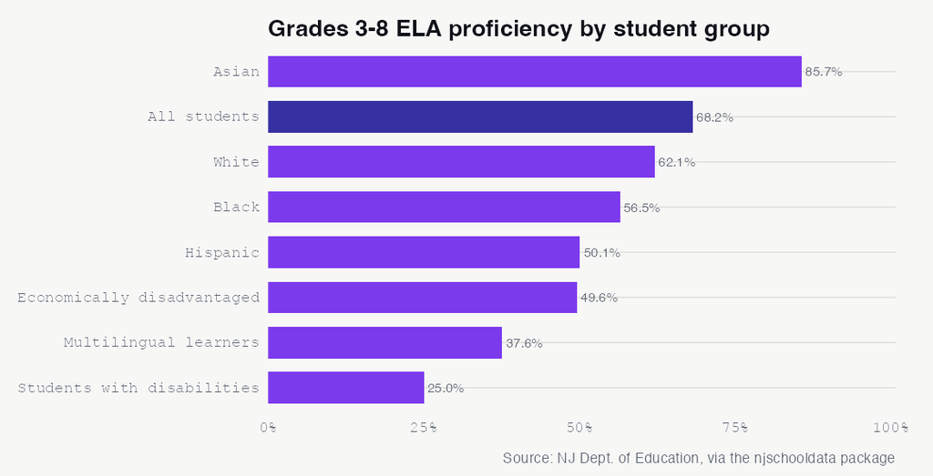

See the underlying data ›

No. 3 DEMOGRAPHICS

## The Share of East Brunswick Students From Low-Income Families Nearly Doubled to 27% in an Affluent District

East Brunswick sits in District Factor Group I, among New Jersey’s most advantaged tiers, yet the count of students qualifying for free or reduced-price lunch grew from about 1,250 to more than 2,100.

East Brunswick is classified in District Factor Group I, the second-highest of New Jersey’s socioeconomic tiers, a label that signals affluence. But the share of its students who are economically disadvantaged has climbed sharply. In 2015, 15.4% of students qualified for free or reduced-price lunch, totaling 1,254 children; by 2026 that share had reached 26.5%, or 2,115 students.

Districts with a DFG I profile often built their budgets and staffing around a more uniformly affluent population. As more than a quarter of East Brunswick’s students now come from families facing economic hardship, will the district’s support services and funding keep pace with a need that has nearly doubled in a decade?

See the underlying data ›

No. 4 DEMOGRAPHICS

## East Brunswick’s White Enrollment Share Fell From 55% to 41% as Hispanic Enrollment More Than Doubled

The district’s largest racial group lost 14 percentage points of share in a decade while its Asian enrollment held steady near a third of all students.

East Brunswick has long been one of Middlesex County’s most diverse suburban systems, and the last decade reshaped its student body again. In 2015, white students made up 55.3% of enrollment; by 2026 that share had fallen to 41.2%, a drop of 14.1 percentage points. Hispanic enrollment moved the other direction, climbing from 6.6% to 15.5%, while the multiracial share rose from 1.0% to 4.1%.

What sets East Brunswick apart from many districts undergoing demographic change is its anchor: Asian students have held remarkably steady, at 32.5% in 2015 and 32.9% in 2026. With the white share now at 41.2% and the Asian share at 32.9%, the two largest groups are closer than at any point in the data, and Hispanic students have grown into the clear third-largest group.

Black enrollment edged up only modestly, from 4.4% to 5.7%. As Hispanic and multiracial enrollment continue to rise and the white share continues to slip, will East Brunswick’s next decade bring the first year with no single racial group above 40%?

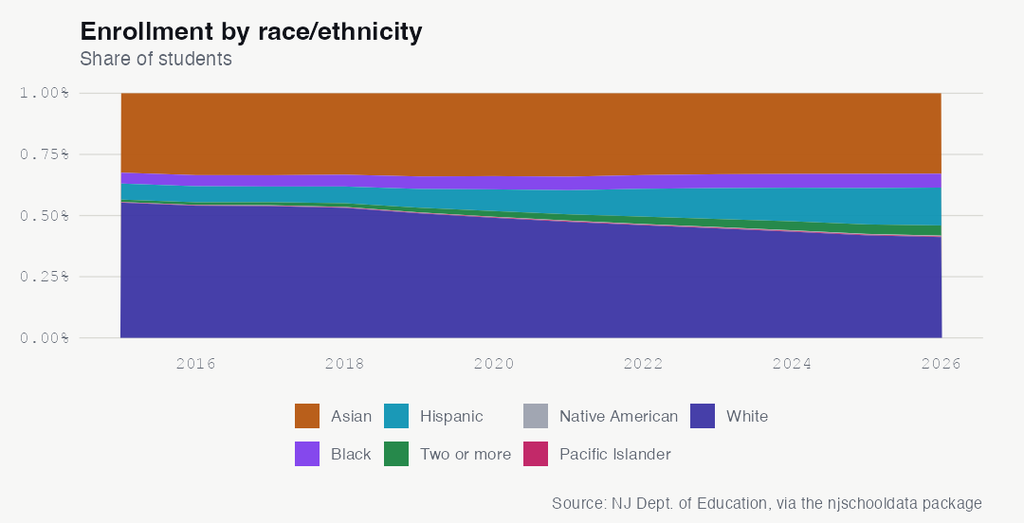

See the underlying data ›

No. 5 GRADUATION

## East Brunswick’s 96% Graduation Rate Ranks in the Bottom Third Among Its Affluent Peers

A graduation rate that would lead many districts places East Brunswick at the 30th percentile of its 103 District Factor Group I peers.

East Brunswick graduated 96.2% of its four-year cohort in 2025, a figure that on its own reads as a success. But measured against the company it keeps, the picture shifts. Among the 103 districts in District Factor Group I, the peer median graduation rate is 97.0%, and East Brunswick’s 96.2% lands at the 30th percentile, in the bottom third of its affluent peer group.

The district’s rate has also been uneven year to year. It rose from 95.5% in 2020 to a high of 97.6% in 2024, then slipped to 96.2% in 2025 even as the graduating cohort grew to 729 students, the largest in the six-year record. That single-year dip pulled the district back below the peer median after briefly exceeding it.

For families weighing a move into a top District Factor Group community, a rate near 96% can look identical to one near 98%, but the gap separates the top of the peer group from the bottom third. Was 2025’s dip a one-year fluctuation, or the start of a wider gap with East Brunswick’s wealthiest peers?

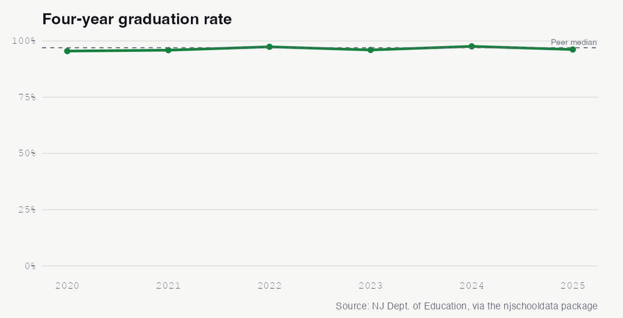

See the underlying data ›

No. 6 EQUITY

Behind a districtwide 96.2% rate, students with disabilities, multilingual learners, and students experiencing homelessness graduated at sharply lower rates in 2025.

East Brunswick’s overall 96.2% graduation rate in 2025 masks wide variation among student groups. Asian students graduated at 97.7% and white students at 97.2%, both above the district total. But Hispanic students graduated at 90.2%, students with disabilities at 88.9%, and students who are economically disadvantaged at 92.9%. Black students graduated at 92.5%, from a cohort of 40.

The widest gaps appear among the district’s smallest and most vulnerable cohorts. Multilingual learners graduated at 65.6% from a cohort of 32, and students experiencing homelessness at 66.7% from a cohort of just 12. From the highest subgroup rate (Asian, 97.7%) to the lowest (multilingual learners, 65.6%) is a spread of 32 percentage points.

Small cohorts mean a single student can move a subgroup rate by several points, so year-to-year swings are expected. But the consistent ordering, with multilingual learners, students experiencing homelessness, and students with disabilities at the bottom, raises a durable question: what supports does East Brunswick have in place to close a gap that, for its most economically and linguistically vulnerable students, runs to roughly 30 points?

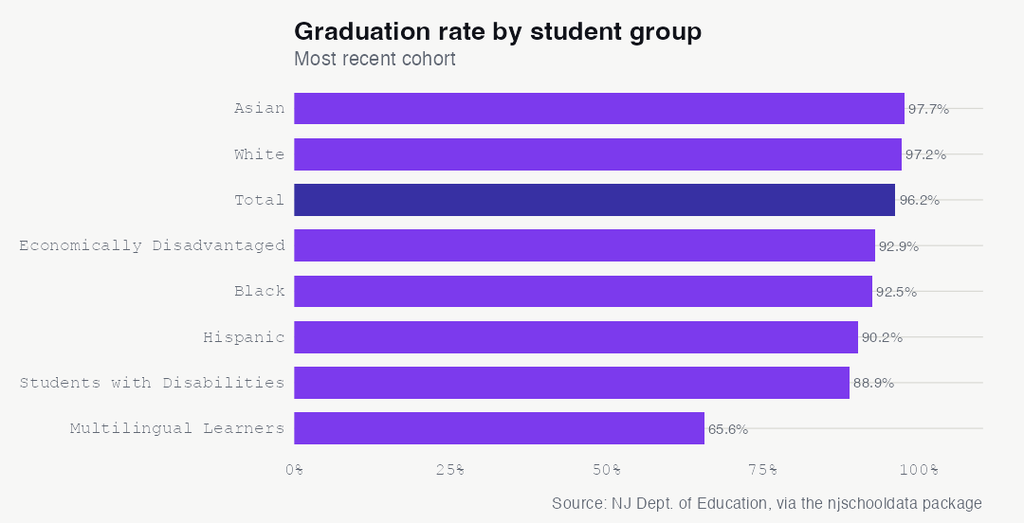

See the underlying data ›

No. 7 FINANCE

## East Brunswick Spends $19,096 Per Pupil, About $1,500 Below Its Affluent-Peer Median

Per-pupil spending has grown 37% since 2014, but the district still ranks in the bottom third of its District Factor Group I peers.

East Brunswick spent $19,096 per pupil in 2024, a figure that has grown 37.3% since 2014, when it stood at $13,909. Yet relative to its peers, the district remains a comparatively lean spender: its 2024 per-pupil spending sits at the 33rd percentile among District Factor Group I districts, where the peer median is $20,613, roughly $1,500 higher.

The spending has climbed in nearly every year of the record, from $13,909 in 2014 to $15,406 in 2019 to $18,416 in 2023 before reaching $19,096 in 2024. Even so, the district has consistently ranked in the middle-to-back of the statewide spending pack, holding ranks in the 40s and 50s throughout the decade.

More than a quarter of East Brunswick’s students now come from economically disadvantaged families, a share that has nearly doubled since 2015. As needs rise but spending stays below the affluent-peer median, will the district close the per-pupil gap with its wealthiest neighbors, or continue to deliver near-top results on a below-median budget?

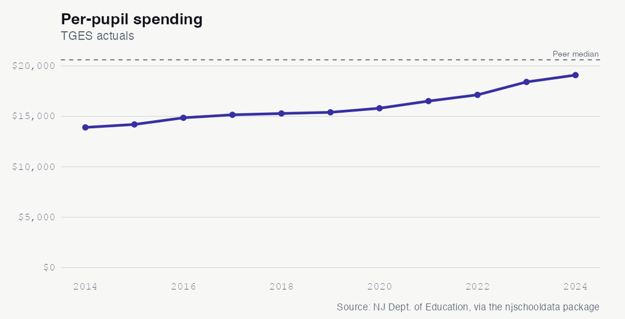

See the underlying data ›

No. 8 ATTENDANCE

## Chronic Absenteeism Fell Back to Its Pre-COVID Level of 8.9% After Peaking at 12.4% in 2023

East Brunswick recovered nearly all of its pandemic-era attendance loss by 2024, though it still trailed the median of its affluent peers.

Chronic absenteeism, the share of students who miss at least 10% of school days, surged across New Jersey during the pandemic, and East Brunswick was no exception. After sitting at 8.9% in 2019, the district’s rate dipped to 5.9% in 2021, then climbed to 10.1% in 2022 and peaked at 12.4% in 2023.

By 2024, the rate had fallen back to 8.9%, exactly its pre-pandemic level, erasing the spike of the prior two years. That recovery stands out against districts where pandemic-era absenteeism proved stubborn. Still, East Brunswick’s 8.9% sat above the 7.8% median of its District Factor Group I peers in 2024.

Returning to the 2019 baseline is a clear marker of stabilization, but the baseline itself runs above the affluent-peer median. Can East Brunswick push chronic absenteeism below its long-standing 8.9% floor, or is that rate the district’s structural norm?

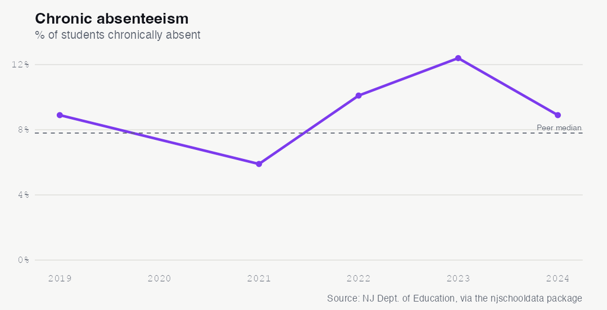

See the underlying data ›

No. 9 COLLEGE READINESS

## 38.5% of East Brunswick Students Hit the Top AP or IB Score in 2024, the Highest Mark in Seven Years

The district’s advanced-coursework success rate reached a seven-year high even as its elementary test scores stayed below pre-pandemic levels.

East Brunswick’s strongest academic signal is in advanced coursework at the high-school level. In 2024, 38.5% of its students scored a 3 or higher on an AP exam or a 4 or higher on an IB exam, the highest mark in the seven-year record. The rate has been durable rather than a one-year spike, sitting at 36.6% in 2018 and holding between 34.4% and 38.5% every year since.

That top-end strength sits alongside a more mixed picture lower down. While more than a third of students are clearing the highest AP and IB benchmarks, the district’s grades 3-8 math proficiency remained at 59.0% in 2024, still below its 2019 level. The two signals describe different ends of the same system: a high-achieving upper tier and an elementary cohort still working back from pandemic losses.

Advanced-coursework strength is one of the clearest markers families use when comparing high schools. With AP and IB success at a seven-year high, can East Brunswick translate that upper-grade momentum down into its elementary classrooms?

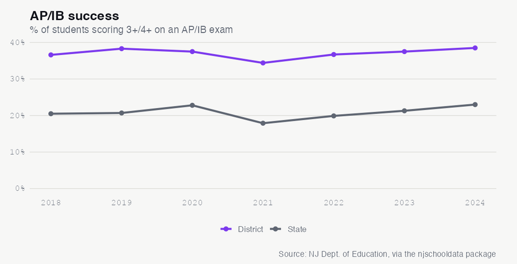

See the underlying data ›

No. 10 FINANCE

## East Brunswick Puts 57% of Spending in the Classroom and Under 10% Into Administration

The district’s 2025 spending breakdown shows most dollars reaching instruction, with a relatively small administrative footprint.

How a district spends its money can matter as much as how much it spends. In 2025, East Brunswick directed 57.3% of its per-pupil spending to the classroom, with another 17.6% going to support services such as counseling, health, and instructional support. Administration accounted for 9.4%, and plant operations and maintenance for 14.0%.

The remaining slices are small: 1.3% on extracurricular activities and 0.2% on equipment. Taken together, classroom and support services made up nearly three-quarters of spending, while the administrative share stayed under 10%.

The district’s staffing ratios fill in the picture, with about 11 students per teacher but 182 students per administrator and 586 per nurse in 2024. As enrollment edges down and the share of students with greater needs rises, will East Brunswick hold its classroom-heavy spending mix, or shift dollars toward the support and health staffing that a changing student body may demand?

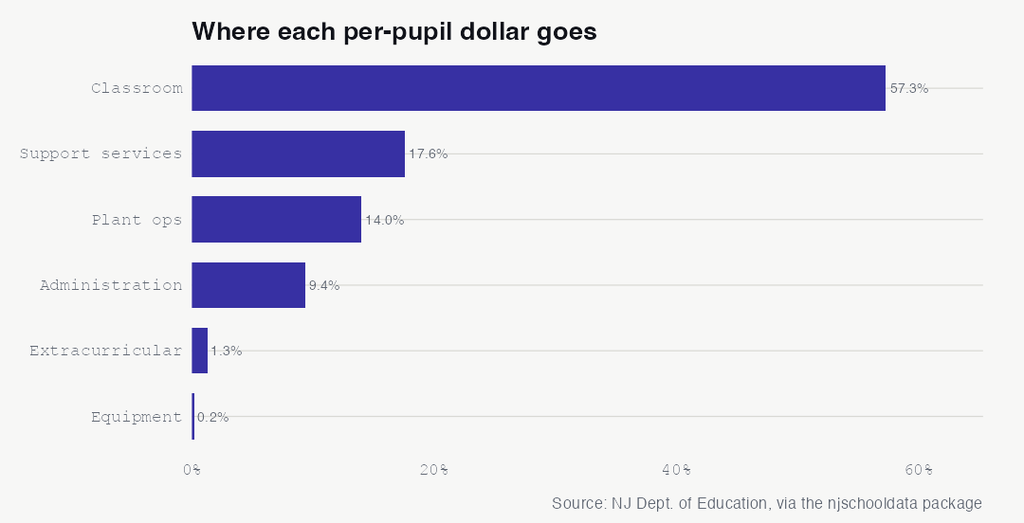

See the underlying data ›

## The Almanac

The full longitudinal record behind the stories above. Every number a reader can check.

### Enrollment (total)

| year | students | yoy | yoy_pct |
| --- | --- | --- | --- |
| 2015 | 8148 | NA | NA |
| 2016 | 8084 | -64 | -0.8 |
| 2017 | 7933 | -151 | -1.9 |
| 2018 | 8020 | 87 | 1.1 |
| 2019 | 8201 | 181 | 2.3 |
| 2020 | 8208 | 7 | 0.1 |
| 2021 | 8029 | -179 | -2.2 |
| 2022 | 8058 | 29 | 0.4 |
| 2023 | 8116 | 58 | 0.7 |
| 2024 | 8122 | 6 | 0.1 |
| 2025 | 8097 | -25 | -0.3 |
| 2026 | 7980 | -117 | -1.4 |

### Demographic share (%) by year

| end_year | white | black | hispanic | asian | native_american | pacific_islander | multiracial |
| --- | --- | --- | --- | --- | --- | --- | --- |
| 2015 | 55.3 | 4.4 | 6.6 | 32.5 | 0.1 | 0.2 | 1 |
| 2016 | 54 | 4.5 | 6.6 | 33.5 | 0.1 | 0.2 | 1.1 |
| 2017 | 53.9 | 4.6 | 6.4 | 33.5 | 0.2 | 0.2 | 1.3 |
| 2018 | 53.2 | 4.8 | 6.8 | 33.3 | 0.1 | 0.2 | 1.5 |
| 2019 | 50.9 | 5.1 | 7.7 | 34 | 0.2 | 0.2 | 1.9 |
| 2020 | 49.1 | 5.4 | 8.9 | 33.9 | 0.2 | 0.3 | 2.3 |
| 2021 | 47.4 | 5.6 | 9.9 | 34.1 | 0.2 | 0.3 | 2.5 |
| 2022 | 46 | 5.6 | 11.4 | 33.5 | 0.2 | 0.3 | 3 |
| 2023 | 44.8 | 5.7 | 12.6 | 33.1 | 0.2 | 0.3 | 3.3 |
| 2024 | 43.4 | 5.6 | 13.7 | 33 | 0.3 | 0.3 | 3.7 |
| 2025 | 41.9 | 5.8 | 14.9 | 32.9 | 0.3 | 0.3 | 3.9 |
| 2026 | 41.2 | 5.7 | 15.5 | 32.9 | 0.3 | 0.3 | 4.1 |

### Special populations (LEP, FRL)

| end_year | subgroup | students | pct |
| --- | --- | --- | --- |
| 2015 | lep | 212 | 2.6 |
| 2015 | free_reduced_lunch | 1254 | 15.4 |
| 2016 | lep | 234 | 2.9 |
| 2016 | free_reduced_lunch | 1280 | 15.8 |
| 2017 | lep | 198 | 2.5 |
| 2017 | free_reduced_lunch | 1246 | 15.7 |
| 2018 | lep | 240 | 3.0 |
| 2018 | free_reduced_lunch | 1364 | 17.0 |
| 2019 | lep | 249 | 3.0 |
| 2019 | free_reduced_lunch | 1504 | 18.3 |
| 2020 | lep | 238 | 2.9 |
| 2020 | free_reduced_lunch | 1527 | 18.6 |
| 2021 | lep | 241 | 3.0 |
| 2021 | free_reduced_lunch | 1566 | 19.5 |
| 2022 | lep | 250 | 3.1 |
| 2022 | free_reduced_lunch | 1402 | 17.4 |
| 2023 | lep | 317 | 3.9 |
| 2023 | free_reduced_lunch | 1753 | 21.6 |
| 2024 | lep | 309 | 3.8 |
| 2024 | free_reduced_lunch | 1697 | 20.9 |
| 2025 | lep | 389 | 4.8 |
| 2025 | free_reduced_lunch | 2040 | 25.2 |
| 2026 | lep | 383 | 4.8 |
| 2026 | free_reduced_lunch | 2115 | 26.5 |

### Graduation rate 4yr (total)

| year | grad_rate | cohort |
| --- | --- | --- |
| 2020 | 95.5 | 688 |
| 2021 | 95.9 | 701 |
| 2022 | 97.4 | 702 |
| 2023 | 96 | 644 |
| 2024 | 97.6 | 678 |
| 2025 | 96.2 | 729 |

### Graduation by subgroup (2025)

| subgroup | grad_rate | cohort |
| --- | --- | --- |
| asian | 97.7 | 264 |
| white | 97.2 | 318 |
| female | 96.6 | 356 |
| total | 96.2 | 729 |
| male | 95.7 | 373 |
| economically disadvantaged | 92.9 | 225 |
| black | 92.5 | 40 |
| multiracial | 92.3 | NA |
| hispanic | 90.2 | 92 |
| students with disabilities | 88.9 | 126 |
| students experiencing homelessness | 66.7 | 12 |
| multilingual learners | 65.6 | 32 |
| american indian | NA | NA |
| migrant students | NA | NA |
| military-connected students | NA | NA |
| non-binary/undesignated gender | NA | NA |
| students in foster care | NA | NA |

### NJGPA high-school proficiency (% proficient+)

| year | test | prof_above | valid |
| --- | --- | --- | --- |
| 2023 | ela | NA | NA |
| 2023 | math | 74.7 | 652 |
| 2024 | ela | NA | NA |
| 2024 | math | 79.8 | 694 |
| 2025 | ela | NA | NA |
| 2025 | math | 79.7 | 709 |

### NJGPA ELA by subgroup (2025)

[output not shown]

### NJSLA grades 3-8 proficiency (% proficient+, enrollment-weighted across grades)

| testing_year | test_name | prof |
| --- | --- | --- |
| 2017 | ela | 75.0 |
| 2017 | math | 67.0 |
| 2018 | math | 68.3 |
| 2019 | ela | 73.5 |
| 2019 | math | 68.1 |
| 2022 | ela | 65.9 |
| 2022 | math | 56.5 |
| 2023 | ela | 68.9 |
| 2023 | math | 59.5 |
| 2024 | ela | 68.2 |
| 2024 | math | 59.0 |

### NJSLA ELA proficiency by subgroup (2024, grades 3-8)

| subgroup | prof |
| --- | --- |
| asian | 85.7 |
| non_ed | 72.9 |
| female | 72.0 |
| total_population | 68.2 |
| male | 64.6 |
| white | 62.1 |
| FORMER - ML | 58.3 |
| other | 57.3 |
| black | 56.5 |
| lep_former | 56.2 |
| hispanic | 50.1 |
| ed | 49.6 |
| lep_current_former | 40.4 |
| MULTILINGUAL LEARNERS | 37.6 |
| special_education | 25.0 |
| sped_accomodations | 23.5 |
| CURRENT - ML | 14.5 |
| lep_current | 6.7 |

### Chronic absenteeism (% chronically absent)

| year | chronic_pct |
| --- | --- |
| 2019 | 8.9 |
| 2021 | 5.9 |
| 2022 | 10.1 |
| 2023 | 12.4 |
| 2024 | 8.9 |

### Disciplinary removals

[output not shown]

### Police notifications (incident counts)

| year | violence | weapons | vandalism | substances | hib | other |
| --- | --- | --- | --- | --- | --- | --- |
| 2019 | 29 | 2 | 6 | 22 | 5 | 9 |
| 2020 | 14 | 1 | 4 | 11 | 3 | 1 |
| 2021 | 3 | 0 | 0 | 2 | 3 | 0 |
| 2022 | 25 | 8 | 2 | 17 | 15 | 1 |
| 2023 | 17 | 3 | 3 | 35 | 12 | 4 |
| 2024 | 16 | 7 | 5 | 10 | 19 | 4 |

### HIB (harassment/intimidation/bullying) investigations

| end_year | alleged | confirmed |
| --- | --- | --- |
| 2019 | 98 | 21 |
| 2020 | 57 | 32 |
| 2021 | 14 | 11 |
| 2022 | 94 | 67 |
| 2023 | 113 | 84 |
| 2024 | 89 | 92 |

### SAT participation (% of grade)

| year | sat_part | state_sat |
| --- | --- | --- |
| 2018 | 85.1 | 72.2 |
| 2019 | 85.6 | 72.1 |
| 2020 | 83.4 | 71.1 |
| 2021 | 67.2 | 45.4 |
| 2022 | 75.1 | 60.8 |
| 2023 | 75.1 | 61.9 |
| 2024 | 73.5 | 62.7 |

### AP/IB & dual enrollment (% of students)

| year | apib_coursework | apib_exam | ap3_ib4 | state_ap3_ib4 | dual |
| --- | --- | --- | --- | --- | --- |
| 2018 | 42.3 | 39.4 | 36.6 | 20.5 | 74.5 |
| 2019 | 44.8 | 41.9 | 38.3 | 20.7 | 76.6 |
| 2020 | 42.4 | 39.4 | 37.5 | 22.8 | 83.2 |
| 2021 | 42.7 | 38.5 | 34.4 | 17.9 | 77.1 |
| 2022 | 43.2 | 40.3 | 36.7 | 19.9 | 78.9 |
| 2023 | 41.6 | 41.3 | 37.5 | 21.3 | 76.3 |
| 2024 | 42.3 | 40.7 | 38.5 | 23 | 72.6 |

### Special education (raw rows; inspect for classification rate)

| end_year | district_id |
| --- | --- |
| 2024 | 1170 |

### Per-pupil spending (TGES actuals)

| year | per_pupil | rank | ade |
| --- | --- | --- | --- |
| 2014 | 13909 | 47 | 8273 |
| 2015 | 14202 | 50 | 8262 |
| 2016 | 14863 | 55 | 8120 |
| 2017 | 15157 | 52 | 8000 |
| 2018 | 15289 | 48 | 8048 |
| 2019 | 15406 | 40 | 8262 |
| 2020 | 15808 | 46 | 8241 |
| 2021 | 16520 | 50 | 8097 |
| 2022 | 17136 | 48 | 8125 |
| 2023 | 18416 | 55 | 8166 |
| 2024 | 19096 | 52 | 8167 |

### Spending composition shares (2025)

| classroom_share | support_services_share | administration_share | plant_ops_share | food_service_share | extracurricular_share | equipment_share |
| --- | --- | --- | --- | --- | --- | --- |
| 57.3 | 17.6 | 9.4 | 14 | NA | 1.3 | 0.2 |

### Staffing ratios

| end_year | student_teacher_district | student_admin_district | student_counselor_district | student_nurse_district |
| --- | --- | --- | --- | --- |
| 2024 | 11:1 | 182:1 | 256:1 | 586:1 |

Back to top